# HR DATA DESCRIPTIVE / EXPLORATORY ANALYSIS

# Executive Summary

The HR executives of a company continuously face problems due to uncertainty associated with a Candidate Joining. The recruitment processes of companies are usually very exhaustive with many individuals spending a lot of time interacting with the candidates. The companies also spend huge money and personnels for this process.

Knowing to a reasonable extent about the likelihood of a candidate joining much earlier in this process, would help the HR consultants plan their efforts by knowing the relative worth of the opportunities (in this case the prospects of a candidate joining).

This Analysis intends to create a model that would predict the probability of a Candidate Joining based on the inputs collected by HR consultants from the applicants and help the HR consultants in making their recruitment efforts more productive. In turn, saving a lot of dollars for the company.

# Descriptive Data Analysis

Here we observe if there are any observable relation-ships between the various predictors / variables on the output result (Joined / Not-Joined). We have made use of the dataset available at - [Link to Dataset](https://www.dropbox.com/s/vurla8dt9t26pu9/HR.csv?dl=0) Here we wouldnt be concluding on anything, we just want to get more familiar with the predictors and how they influence the outcome

## Whether Date of Joining Extension Requested, Duration to accept the offer, Notice Period

In the below graphs we have plotted the Status against Whether Date of Joining Extension was requested, Duration to accept the offer and Notice Period. The graph on the left side indicates the absolute figures and the ones on the right show the relative percentages.

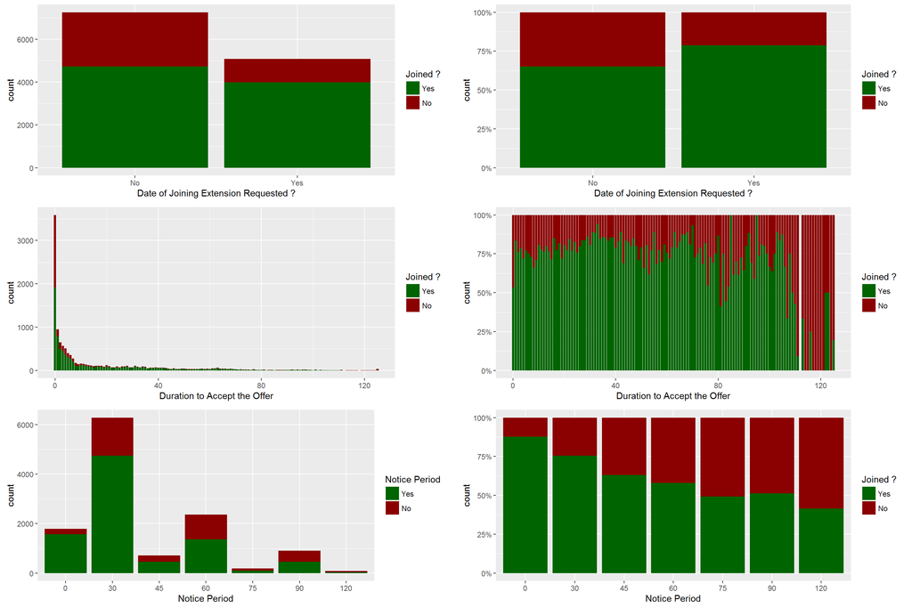

As we can observe -

1. Whether Date of Joining Extension Requested - It appears that people who have asked for Joining Date extension are more likely to join.
2. Duration to accept the offer - Most of the candidates accepted the offer on the same day. The number of candiates accepting the offer decreases exponentially as the number of days increases. Also, As the Duration to accept the offer increases, the %age of people who joined slightly decreases till 100 Day Notice Period. After that there is a huge trough.
3. Notice Period - Majority of the candidates have a 30 Day Notice Period. While there are also surprisingly cases with 120 Day Notice Period. As the Notice Period increases, the %age of people who joined decreases.

## Offered band, Candidate relocate actual, Joining Bonus

In the below graphs we have plotted the Status against Offered band, If the Candidate was asked to relocate and Joining Bonus. The graph on the left side indicates the absolute figures and the ones on the right show the relative percentages.

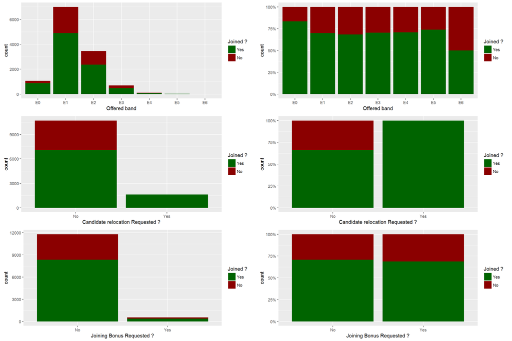

## Candidate Source, Location, Line of Business, Gender

In the below graphs we have plotted the Status against Candidate Source, Location, Line of Business and Gender. The graph on the left side indicates the absolute figures and the ones on the right show the relative percentages.

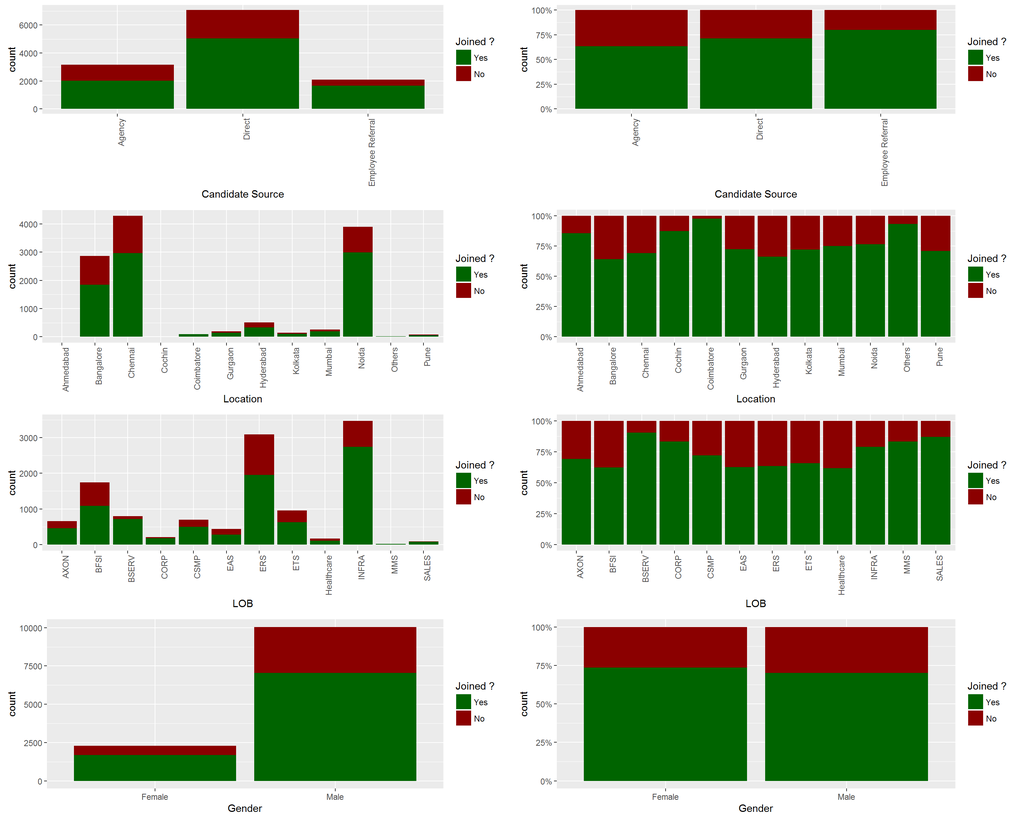

## CTC Difference, Years of Exp. and Age

In the below jitter plots we have plotted the Status (Not Joined, Joined) against CTC Difference, Years of Exp. and Age.

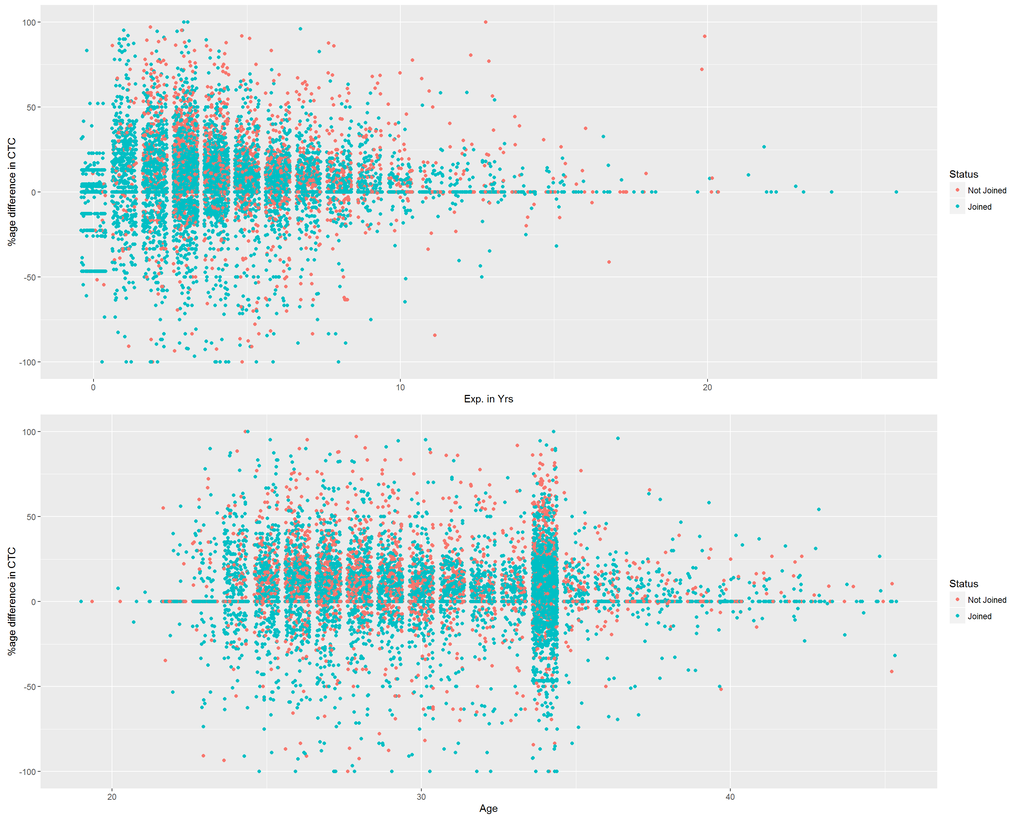

# Model Fitting

Now we would try to fit a model that can best predict the Probability of a Candidate Joining, if we pass some of the key parameters to it. We would get these parameters from the HR team who in-turn collects them from the candidates.

Such a model would be helpful to understand what is the relative likelihood of a candidate joining so that the HR team can base their further actions based on that.

## Logistic Regression

To assess the relative likelihood of a candidate joining, we would make use of the Logistic Regression model as we essentially have a Binomial Data (Joined / Not Joined).

Below are the accuracy figures that we acheived.

## On Training Set -

```
## [1] "Training Accuracy 0.75642807505212"
```

## On Testing Set -

```
## [1] "Testing Accuracy 0.76669370100027"
```

We will now apply this model on the entire dataset (for purely achademic purpose) to obtain the prediction results on a binary scale - Is the candidate likely to join or not .. Yes or No ? We have created the below map using a simple assumption that a candidate is likely to join if the probalility of joining is greater than 50%

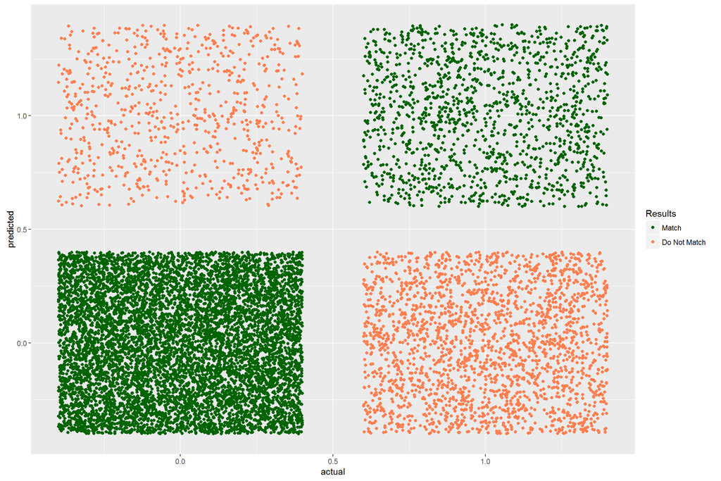

|  | Measure Values |
| --- | --- |
| Accuracy | 0.76 |
| Kappa | 0.34 |
| AccuracyLower | 0.75 |
| AccuracyUpper | 0.77 |
| AccuracyNull | 0.83 |
| AccuracyPValue | 1.00 |
| McnemarPValue | 0.00 |